# Customer Credit Card Prediction

In this notebook, there will be 4 main focuses which are:-

1. **EDA**
2. **Feature Engineering**
   - Feature Encoding
   - Scaling
   - Decomposition (PCA))
3. **Modelling & Hyperparameter Tuning**
4. **Evaluation Metrics**
   - Precision-Recall Curve
   - Receiver Operating Characteristic curve (ROC))
   - AUC

**Summary**

P/s: I am new in this data science field, please feel free to give better suggestions or if you happen to find any mistake along this notebook, feel free to comment. Finally, got to apply the knowledge I have gained from my Data Science certificate in this dataset. Now, let's dig in!

```python
# This Python 3 environment comes with many helpful analytics libraries installed
# It is defined by the kaggle/python Docker image: https://github.com/kaggle/docker-python
# For example, here's several helpful packages to load

import numpy as np # linear algebra
import pandas as pd # data processing, CSV file I/O (e.g. pd.read_csv)

# Input data files are available in the read-only "../input/" directory
# For example, running this (by clicking run or pressing Shift+Enter) will list all files under the input directory

import os
for dirname, _, filenames in os.walk('/kaggle/input'):
    for filename in filenames:
        print(os.path.join(dirname, filename))

# You can write up to 20GB to the current directory (/kaggle/working/) that gets preserved as output when you create a version using "Save & Run All"
# You can also write temporary files to /kaggle/temp/, but they won't be saved outside of the current session
```

```
/kaggle/input/credit-card-customers/BankChurners.csv
```

```python
# import necessary packages

import matplotlib.pyplot as plt
from matplotlib.ticker import MaxNLocator
import seaborn as sns
plt.style.use('default')


import warnings
warnings.simplefilter(action='ignore', category=FutureWarning)
```

# Exploratory Data Analysis - EDA

We will explore the data first, to get an overall understanding of the data

```python
# read the csv using panda
df_cred = pd.read_csv("/kaggle/input/credit-card-customers/BankChurners.csv")

# let's check the shape and the last 5 rows of the data
print(df_cred.shape)
df_cred.tail()
```

```
(10127, 23)
```

|  | CLIENTNUM | Attrition_Flag | Customer_Age | Gender | Dependent_count | Education_Level | Marital_Status | Income_Category | Card_Category | Months_on_book | ... | Credit_Limit | Total_Revolving_Bal | Avg_Open_To_Buy | Total_Amt_Chng_Q4_Q1 | Total_Trans_Amt | Total_Trans_Ct | Total_Ct_Chng_Q4_Q1 | Avg_Utilization_Ratio | Naive_Bayes_Classifier_Attrition_Flag_Card_Category_Contacts_Count_12_mon_Dependent_count_Education_Level_Months_Inactive_12_mon_1 | Naive_Bayes_Classifier_Attrition_Flag_Card_Category_Contacts_Count_12_mon_Dependent_count_Education_Level_Months_Inactive_12_mon_2 |
| --- | --- | --- | --- | --- | --- | --- | --- | --- | --- | --- | --- | --- | --- | --- | --- | --- | --- | --- | --- | --- | --- |
| 10122 | 772366833 | Existing Customer | 50 | M | 2 | Graduate | Single | $40K - $60K | Blue | 40 | ... | 4003.0 | 1851 | 2152.0 | 0.703 | 15476 | 117 | 0.857 | 0.462 | 0.000191 | 0.999810 |
| 10123 | 710638233 | Attrited Customer | 41 | M | 2 | Unknown | Divorced | $40K - $60K | Blue | 25 | ... | 4277.0 | 2186 | 2091.0 | 0.804 | 8764 | 69 | 0.683 | 0.511 | 0.995270 | 0.004729 |
| 10124 | 716506083 | Attrited Customer | 44 | F | 1 | High School | Married | Less than $40K | Blue | 36 | ... | 5409.0 | 0 | 5409.0 | 0.819 | 10291 | 60 | 0.818 | 0.000 | 0.997880 | 0.002118 |
| 10125 | 717406983 | Attrited Customer | 30 | M | 2 | Graduate | Unknown | $40K - $60K | Blue | 36 | ... | 5281.0 | 0 | 5281.0 | 0.535 | 8395 | 62 | 0.722 | 0.000 | 0.996710 | 0.003294 |
| 10126 | 714337233 | Attrited Customer | 43 | F | 2 | Graduate | Married | Less than $40K | Silver | 25 | ... | 10388.0 | 1961 | 8427.0 | 0.703 | 10294 | 61 | 0.649 | 0.189 | 0.996620 | 0.003377 |

5 rows × 23 columns

```python
# Drop columns that are unneccessary
# Clientnum and the last two Naive Bayes columns is not related as been explained in the data description

df_cred.drop(['CLIENTNUM', 'Naive_Bayes_Classifier_Attrition_Flag_Card_Category_Contacts_Count_12_mon_Dependent_count_Education_Level_Months_Inactive_12_mon_1',
              'Naive_Bayes_Classifier_Attrition_Flag_Card_Category_Contacts_Count_12_mon_Dependent_count_Education_Level_Months_Inactive_12_mon_2'],
             axis=1, inplace=True)

print(df_cred.shape)
```

```
(10127, 20)
```

```python
# Recommended to check the table after dropping column(s) on another cell because of the drop is inplace=True
# So, to avoid errors when running the cell for multiple times

# List of columns
print(df_cred.columns)
print("")

# Let's see if there is any missing values
print(df_cred.info())

# Let's see the statistics for numerical values
display(df_cred.describe())
```

```
Index(['Attrition_Flag', 'Customer_Age', 'Gender', 'Dependent_count',
       'Education_Level', 'Marital_Status', 'Income_Category', 'Card_Category',
       'Months_on_book', 'Total_Relationship_Count', 'Months_Inactive_12_mon',
       'Contacts_Count_12_mon', 'Credit_Limit', 'Total_Revolving_Bal',
       'Avg_Open_To_Buy', 'Total_Amt_Chng_Q4_Q1', 'Total_Trans_Amt',
       'Total_Trans_Ct', 'Total_Ct_Chng_Q4_Q1', 'Avg_Utilization_Ratio'],
      dtype='object')

<class 'pandas.core.frame.DataFrame'>
RangeIndex: 10127 entries, 0 to 10126
Data columns (total 20 columns):
 #   Column                    Non-Null Count  Dtype
---  ------                    --------------  -----
 0   Attrition_Flag            10127 non-null  object
 1   Customer_Age              10127 non-null  int64
 2   Gender                    10127 non-null  object
 3   Dependent_count           10127 non-null  int64
 4   Education_Level           10127 non-null  object
 5   Marital_Status            10127 non-null  object
 6   Income_Category           10127 non-null  object
 7   Card_Category             10127 non-null  object
 8   Months_on_book            10127 non-null  int64
 9   Total_Relationship_Count  10127 non-null  int64
 10  Months_Inactive_12_mon    10127 non-null  int64
 11  Contacts_Count_12_mon     10127 non-null  int64
 12  Credit_Limit              10127 non-null  float64
 13  Total_Revolving_Bal       10127 non-null  int64
 14  Avg_Open_To_Buy           10127 non-null  float64
 15  Total_Amt_Chng_Q4_Q1      10127 non-null  float64
 16  Total_Trans_Amt           10127 non-null  int64
 17  Total_Trans_Ct            10127 non-null  int64
 18  Total_Ct_Chng_Q4_Q1       10127 non-null  float64
 19  Avg_Utilization_Ratio     10127 non-null  float64
dtypes: float64(5), int64(9), object(6)
memory usage: 1.5+ MB
None
```

|  | Customer_Age | Dependent_count | Months_on_book | Total_Relationship_Count | Months_Inactive_12_mon | Contacts_Count_12_mon | Credit_Limit | Total_Revolving_Bal | Avg_Open_To_Buy | Total_Amt_Chng_Q4_Q1 | Total_Trans_Amt | Total_Trans_Ct | Total_Ct_Chng_Q4_Q1 | Avg_Utilization_Ratio |
| --- | --- | --- | --- | --- | --- | --- | --- | --- | --- | --- | --- | --- | --- | --- |
| count | 10127.000000 | 10127.000000 | 10127.000000 | 10127.000000 | 10127.000000 | 10127.000000 | 10127.000000 | 10127.000000 | 10127.000000 | 10127.000000 | 10127.000000 | 10127.000000 | 10127.000000 | 10127.000000 |
| mean | 46.325960 | 2.346203 | 35.928409 | 3.812580 | 2.341167 | 2.455317 | 8631.953698 | 1162.814061 | 7469.139637 | 0.759941 | 4404.086304 | 64.858695 | 0.712222 | 0.274894 |
| std | 8.016814 | 1.298908 | 7.986416 | 1.554408 | 1.010622 | 1.106225 | 9088.776650 | 814.987335 | 9090.685324 | 0.219207 | 3397.129254 | 23.472570 | 0.238086 | 0.275691 |
| min | 26.000000 | 0.000000 | 13.000000 | 1.000000 | 0.000000 | 0.000000 | 1438.300000 | 0.000000 | 3.000000 | 0.000000 | 510.000000 | 10.000000 | 0.000000 | 0.000000 |
| 25% | 41.000000 | 1.000000 | 31.000000 | 3.000000 | 2.000000 | 2.000000 | 2555.000000 | 359.000000 | 1324.500000 | 0.631000 | 2155.500000 | 45.000000 | 0.582000 | 0.023000 |
| 50% | 46.000000 | 2.000000 | 36.000000 | 4.000000 | 2.000000 | 2.000000 | 4549.000000 | 1276.000000 | 3474.000000 | 0.736000 | 3899.000000 | 67.000000 | 0.702000 | 0.176000 |
| 75% | 52.000000 | 3.000000 | 40.000000 | 5.000000 | 3.000000 | 3.000000 | 11067.500000 | 1784.000000 | 9859.000000 | 0.859000 | 4741.000000 | 81.000000 | 0.818000 | 0.503000 |
| max | 73.000000 | 5.000000 | 56.000000 | 6.000000 | 6.000000 | 6.000000 | 34516.000000 | 2517.000000 | 34516.000000 | 3.397000 | 18484.000000 | 139.000000 | 3.714000 | 0.999000 |

### Visualise the frequency of each categorical features

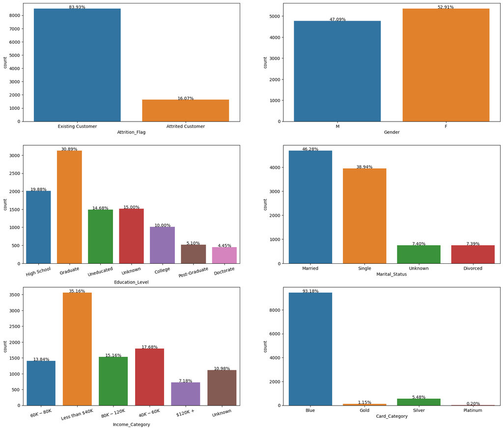

```python
# We want to see the frequency and unique features of all categorical variable in the data by plotting graph

def pltCountplot(category):

    fig, axis = plt.subplots(3, 2, figsize=(20,17))  # graph 3 by 2

    index = 0
    for i in range(3):
        for j in range(2):

            ax = sns.countplot(category[index], data=df_cred, ax=axis[i][j])

            if category[index] in ['Education_Level', 'Income_Category']:  # because the x-label of edu and income category is quite long, so we need to rotate it a bit for visually pleasing
                for item in ax.get_xticklabels():
                    item.set_rotation(15)

            for p in ax.patches:
                height = p.get_height()
                ax.text(p.get_x()+p.get_width()/2.,
                        height + 3,
                        '{:1.2f}%'.format(height/len(df_cred)*100),
                        ha="center")
            index += 1


category = ['Attrition_Flag', 'Gender', 'Education_Level', 'Marital_Status', 'Income_Category', 'Card_Category']
pltCountplot(category)
```

### Visualise the features frequency of customer who attrited between the categorical features

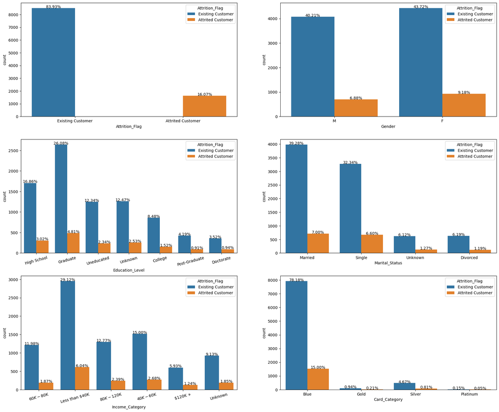

```python
def pltCountplot_attrited(category, attrition_flag):

    fig, axis = plt.subplots(3, 2, figsize=(22,18))  # graph 3 by 2

    index = 0
    for i in range(3):
        for j in range(2):

            ax = sns.countplot(category[index], data=df_cred, hue=attrition_flag, ax=axis[i][j])

            if category[index] in ['Education_Level', 'Income_Category']:
                for item in ax.get_xticklabels():
                    item.set_rotation(15)

            for p in ax.patches:
                height = p.get_height()
                ax.text(p.get_x()+p.get_width()/2.,
                        height + 3,
                        '{:1.2f}%'.format(height/len(df_cred)*100),
                        ha="center")
            index += 1


pltCountplot_attrited(category, 'Attrition_Flag')
```

#### Observations

1. We can see clearly here that attrited customer is significantly less than the existing customer on all the categorical features.
2. For the education level, the ratio of customer who attrited is roughly the same from high school up until college level. And, slowly decreasing in ratio from postgraduate to doctorate level.
3. Ratio of attrited customer in the '60K-80K' income category, is 6.41 where it is higher than the rest income range (exclude Unknown).

These are observations we can see within the respective category only.

### Now, let's see the features correlation between the numerical features

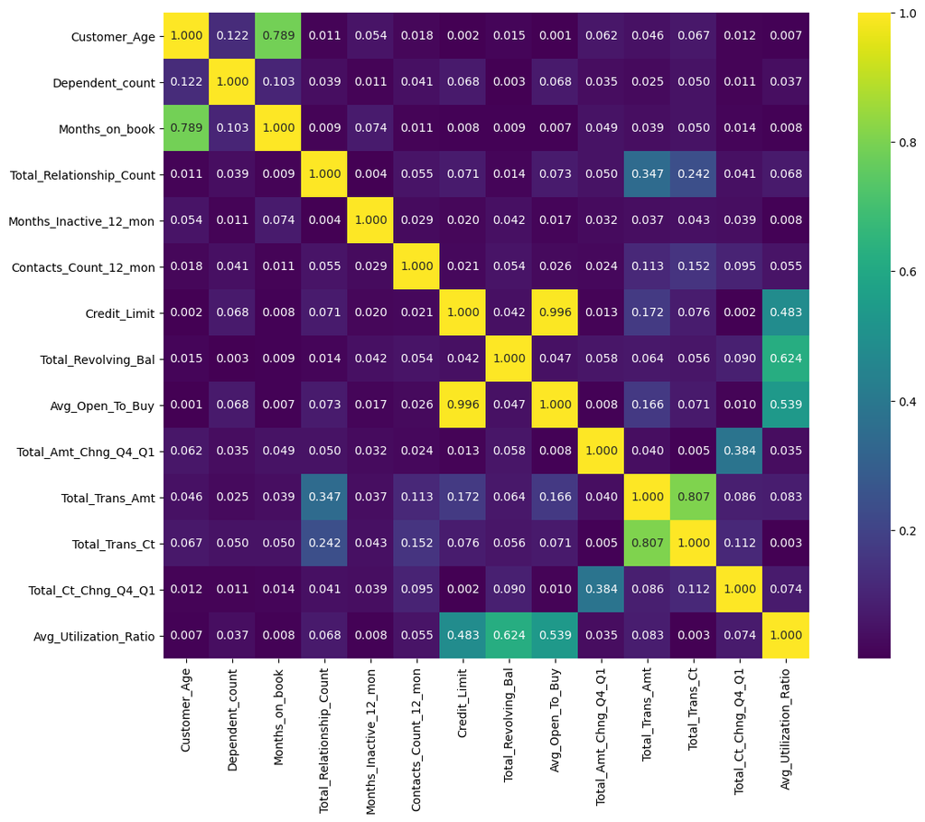

```python
numerical = ['Customer_Age','Dependent_count', 'Months_on_book', 'Total_Relationship_Count', 'Months_Inactive_12_mon',
             'Contacts_Count_12_mon', 'Credit_Limit', 'Total_Revolving_Bal', 'Avg_Open_To_Buy', 'Total_Amt_Chng_Q4_Q1',
             'Total_Trans_Amt', 'Total_Trans_Ct', 'Total_Ct_Chng_Q4_Q1', 'Avg_Utilization_Ratio']


corr_data = df_cred.loc[:, numerical].corr()

plt.figure(figsize=(15,10))
sns.heatmap(corr_data.abs(), annot=True, fmt='.3f',cmap='viridis',square=True)
plt.show()
```

#### Observations

There are 8 numerical features who correlated above 0.5, which are:-

1. Average Open To Buy (Credit Line) and Credit Limit (on the card) = 0.996, high positive correlation.
2. Total Transaction Amount and Total Transaction Count = 0.807, high positive correlation.
3. Months on book and Customer age = 0.789, positive correlation.
4. Total revolving balance and Average Utilization Ratio = 0.624, slightly positive correlation.

# Feature Engineering

## Feature/ Data Encoding

For the 6 categorical features, I have divided it into 2 sub-categories which are Nominal and Ordinal. Nominal categories will be using dummy function for non-binary and map function for binary categorical. Whereas, Ordinal will be mapped to their respective level according to their respective category.

- Nominal: Attrition_Flag, Gender, and Marital_Status
- Ordinal: Education_Level, Income_Category, and Card_Category

#### Binary categorical (Nominal)

```python
# create new df
df_cred_updated = pd.DataFrame()

# Target variable
# Customer whom attrited will be replaced to 1, else 0
df_cred_updated["Attrit"] = df_cred.Attrition_Flag.map({"Attrited Customer":1, "Existing Customer":0})

# Gender
df_cred_updated["Gender"] = df_cred.Gender.map({"M":1, "F":0})
```

#### Dummy variable (Nominal)

```python
dum_marital = pd.get_dummies(df_cred.Marital_Status, prefix='marital', drop_first=True)
dum_marital.head(2)
```

|  | marital_Married | marital_Single | marital_Unknown |
| --- | --- | --- | --- |
| 0 | 1 | 0 | 0 |
| 1 | 0 | 1 | 0 |

#### Ordinal Categorical

```python
# ordinal -- ordinal variable because it has natural ordering

df_cred_updated['Education_Level'] = df_cred.Education_Level.map({'Uneducated':1, 'High School':2, 'College':3,
                                                         'Graduate':4, 'Post-Graduate':5, 'Doctorate':6, 'Unknown':7})
df_cred_updated['Income_Category'] = df_cred.Income_Category.map({'Less than $40K':1, '$40K - $60K':2, '$60K - $80K':3,
                                                          '$80K - $120K':4, '$120K +':5, 'Unknown':6})
df_cred_updated['Card_Category'] = df_cred.Card_Category.map({'Blue':1, 'Silver':2, 'Gold':3, 'Platinum':4})

df_cred_updated = pd.concat([df_cred_updated, dum_marital, df_cred[numerical]], axis=1)
```

```python
# Let's see the updated credit data in more detail
print("Shape of updated credit dataset:", df_cred_updated.shape)
print("\nList of updated columns: \n\n", df_cred_updated.columns)
display(df_cred_updated.head(5))
```

```
Shape of updated credit dataset: (10127, 22)

List of updated columns:

 Index(['Attrit', 'Gender', 'Education_Level', 'Income_Category',
       'Card_Category', 'marital_Married', 'marital_Single', 'marital_Unknown',
       'Customer_Age', 'Dependent_count', 'Months_on_book',
       'Total_Relationship_Count', 'Months_Inactive_12_mon',
       'Contacts_Count_12_mon', 'Credit_Limit', 'Total_Revolving_Bal',
       'Avg_Open_To_Buy', 'Total_Amt_Chng_Q4_Q1', 'Total_Trans_Amt',
       'Total_Trans_Ct', 'Total_Ct_Chng_Q4_Q1', 'Avg_Utilization_Ratio'],
      dtype='object')
```

|  | Attrit | Gender | Education_Level | Income_Category | Card_Category | marital_Married | marital_Single | marital_Unknown | Customer_Age | Dependent_count | ... | Months_Inactive_12_mon | Contacts_Count_12_mon | Credit_Limit | Total_Revolving_Bal | Avg_Open_To_Buy | Total_Amt_Chng_Q4_Q1 | Total_Trans_Amt | Total_Trans_Ct | Total_Ct_Chng_Q4_Q1 | Avg_Utilization_Ratio |
| --- | --- | --- | --- | --- | --- | --- | --- | --- | --- | --- | --- | --- | --- | --- | --- | --- | --- | --- | --- | --- | --- |
| 0 | 0 | 1 | 2 | 3 | 1 | 1 | 0 | 0 | 45 | 3 | ... | 1 | 3 | 12691.0 | 777 | 11914.0 | 1.335 | 1144 | 42 | 1.625 | 0.061 |
| 1 | 0 | 0 | 4 | 1 | 1 | 0 | 1 | 0 | 49 | 5 | ... | 1 | 2 | 8256.0 | 864 | 7392.0 | 1.541 | 1291 | 33 | 3.714 | 0.105 |
| 2 | 0 | 1 | 4 | 4 | 1 | 1 | 0 | 0 | 51 | 3 | ... | 1 | 0 | 3418.0 | 0 | 3418.0 | 2.594 | 1887 | 20 | 2.333 | 0.000 |
| 3 | 0 | 0 | 2 | 1 | 1 | 0 | 0 | 1 | 40 | 4 | ... | 4 | 1 | 3313.0 | 2517 | 796.0 | 1.405 | 1171 | 20 | 2.333 | 0.760 |
| 4 | 0 | 1 | 1 | 3 | 1 | 1 | 0 | 0 | 40 | 3 | ... | 1 | 0 | 4716.0 | 0 | 4716.0 | 2.175 | 816 | 28 | 2.500 | 0.000 |

5 rows × 22 columns

## Feature Scaling

3 scaler will be used to scale the data:-

- Standard Scaler
- MinMax Scaler
- Power Transformer Scaler

```python
from sklearn.model_selection import train_test_split
from sklearn.preprocessing import StandardScaler, MinMaxScaler, PowerTransformer

from sklearn.pipeline import make_pipeline


X = df_cred_updated.drop('Attrit', axis=1)
y = df_cred_updated['Attrit']

X_train, X_test, y_train, y_test = train_test_split(X, y, random_state=42)


# Feature scaling -- Standard Scaler
scaler_S = StandardScaler().fit(X_train)
X_train_s = scaler_S.transform(X_train)
X_test_s = scaler_S.transform(X_test)


# Feature scaling -- MinMax Scaler
scaler_MM = MinMaxScaler().fit(X_train)
X_train_mm = scaler_MM.transform(X_train)
X_test_mm = scaler_MM.transform(X_test)


# Feature scaling -- Power Transformer
scaler_PT = PowerTransformer().fit(X_train)
X_train_pt = scaler_PT.transform(X_train)
X_test_pt = scaler_PT.transform(X_test)
```

## Decomposition (PCA)

Choose the most important feature components that preserves the maximal data variance in the dataset.

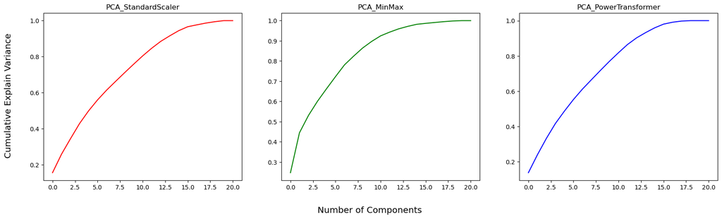

```python
from sklearn.decomposition import PCA

# PCA -- Standard Scaler, MinMax, PT
pca_s = PCA().fit(X_train_s)
pca_mm = PCA().fit(X_train_mm)
pca_pt = PCA().fit(X_train_pt)


# Plot the graph to see the number of components needed to explain the most data variance
fig, axs = plt.subplots(1, 3, figsize=(20,5))
fig.text(0.5, -0.04, 'Number of Components', ha='center', size="x-large")
fig.text(0.08, 0.5, 'Cumulative Explain Variance', va='center', rotation='vertical', size="x-large")

axs[0].plot(np.cumsum(pca_s.explained_variance_ratio_), color="red")
axs[0].set_title("PCA_StandardScaler")
axs[1].plot(np.cumsum(pca_mm.explained_variance_ratio_), color="green")
axs[1].set_title("PCA_MinMax")
axs[2].plot(np.cumsum(pca_pt.explained_variance_ratio_), color="blue")
axs[2].set_title("PCA_PowerTransformer");


# do the PCA first so that we know which feature is most important -- plus, dont want our model to be complicated
# If we add these irrelevant features in the model, it will just make the model worst (Garbage In Garbage Out)
```

#### Observations

1. PCA_StandardScaler - We can see, with the updated dataset. The first 14 components contain approximately 90% of the variance while we need around 17 components to describe close to 100% of the variance.
2. PCA_MinMax - For the PCA after scaled using MinMax, the first 10 components contain approximately 90% of the variance while we need around 16 components to describe close to 100% of the variance.
3. PCA_PowerTransformer - Lastly, for the PCA after scaled using PowerTransformer, the first 13 components contain approximately 90% of the variance while we need around 16 components to describe close to 100% of the variance.

Hence, by looking at this plot for a high-dimensional dataset, we can choose how many components needed to train our model. It is useful in reducing redundancy present in the dataset plus it also help to improve the time execution.

```python
# PCA -- SS
pca1_s = PCA(n_components=14)
X_train_s_pca = pca1_s.fit_transform(X_train_s)
X_test_s_pca = pca1_s.transform(X_test_s)

# PCA -- MM
pca1_mm = PCA(n_components=10)
X_train_mm_pca = pca1_mm.fit_transform(X_train_mm)
X_test_mm_pca = pca1_mm.transform(X_test_mm)

# PCA -- PT
pca1_pt = PCA(n_components=13)
X_train_pt_pca = pca1_pt.fit_transform(X_train_pt)
X_test_pt_pca = pca1_pt.transform(X_test_pt)


# Shape
print("Original shape: ", X_train.shape)
print("\nAfter PCA & SS: ", X_train_s_pca.shape)
print("After PCA & MM: ", X_train_mm_pca.shape)
print("After PCA & PT: ", X_train_pt_pca.shape)
```

```
Original shape:  (7595, 21)

After PCA & SS:  (7595, 14)
After PCA & MM:  (7595, 10)
After PCA & PT:  (7595, 13)
```

#### Below is the visualization of the first 14 importance features after being scaled using Standard Scaler

We can see clearly the first component hold the most cumulative variance of features compared to the last component.

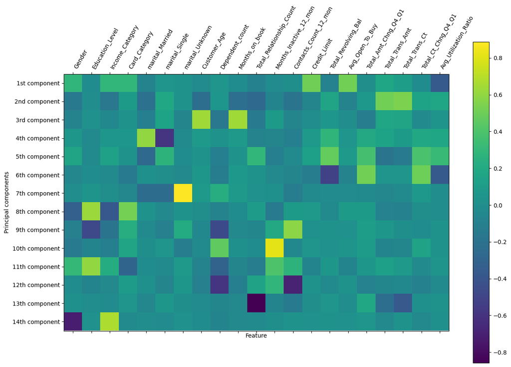

```python
plt.figure(figsize=(15,10))
plt.matshow(pca1_s.components_, cmap='viridis', fignum=1)
plt.yticks([0, 1, 2, 3, 4, 5, 6, 7, 8, 9, 10, 11, 12, 13],
           ["1st component", "2nd component", "3rd component", "4th component", "5th component",
            "6th component", "7th component", "8th component", "9th component", "10th component",
            "11th component", "12th component", "13th component", "14th component"])
plt.colorbar()
plt.xticks(range(21), df_cred_updated.iloc[:, 1:], rotation=60, ha='left')
plt.xlabel("Feature")
plt.ylabel("Principal components")
plt.show()
```

# Modelling & Hyperparameter Tuning

### Preamble -- imbalanced dataset

Since, we have an imbalanced dataset where Existing Customer:8500 and Attrited Customer:1627. We will handle it by applying KFold and over-sampling (SMOTE) method to the dataset. Our aim is to find a classifier with a good recall (i.e. we want our classifier to find as many attrited cases as it can). However, we need to be aware when using this metric because we do not want to simply label people who are going to attrit their credit card.

#### Note: We use dataset that is being scaled using StandardScaler and PCA(14)

### Let's Standardizing our splits

Let's make sure that our results are consistent as we try different methods. It is a little simpler to have cv=5 in all of our grid searches and cross-validations, but we will get different splits each time.

If we use cv=kf, where kf is a KFold object we can ensure that we get the same splits each time.

KFold cross-validation will be applied first before data resampling being done. It is important to avoid the data overfit our model to a specific artificial bootstrapping result. Only by resampling the data repeatedly, randomness can be introduced into the dataset to make sure that there won’t be an overfitting problem.

```python
""" From here, we can see our targets are preamble dataset. So, we use over-sampling (SMOTE) method to
balance the dataset by increasing the size of the rare sample, in our case Churned size.

{0:Existing, 1=Churned}"""


from collections import Counter
Counter(y)
```

```
Counter({0: 8500, 1: 1627})
```

```python
# Import necessary packages

from sklearn.model_selection import cross_val_score, KFold, GridSearchCV
from imblearn.pipeline import Pipeline, make_pipeline
from imblearn.over_sampling import SMOTE
from sklearn.metrics import accuracy_score, precision_score, recall_score, f1_score


kf = KFold(n_splits=5)
```

```python
# General function for all model except forest
def imba_pipe(model):
    imba_pipeline = make_pipeline(SMOTE(random_state=42), model)
    return cross_val_score(imba_pipeline, X_train_s_pca, y_train, scoring="recall", cv=kf)

# Function for forest model -- the model does not use scaled data or dimension reduction data
def imba_pipe_forest(model):
    imba_pipeline = make_pipeline(SMOTE(random_state=42), model)
    return cross_val_score(imba_pipeline, X_train, y_train, scoring="recall", cv=kf)

# Function to fit the train and test dataset to models
def imba_pipe_fit(model):
    imba_pipeline = Pipeline(steps=[('smote', SMOTE(random_state=42)),
                                    ('model', model)
                                   ])
    return imba_pipeline
```

### 1. KNeighbors Classifier

```python
from sklearn.neighbors import KNeighborsClassifier

# Before GridSearchCV
knn = KNeighborsClassifier(n_neighbors=100)
knn_recall = imba_pipe(knn)
print("Array of KNN recall score after KFold and resample: ", knn_recall)
print("Mean of array KNN recall score: ", round(knn_recall.mean(), 2))
```

```
Array of KNN recall score after KFold and resample:  [0.85950413 0.87826087 0.87843137 0.83333333 0.85892116]
Mean of array KNN recall score:  0.86
```

```python
# Find the best hypertuning params -- using GridSearchCV
knn1 = KNeighborsClassifier()
knn_params = {"model__n_neighbors":[2,5,10,87,100],
              "model__weights":["uniform", "distance"],
              "model__p":[1,2]
             }

knn_grid = GridSearchCV(imba_pipe_fit(knn1), knn_params, cv=kf, scoring="recall")
knn_grid.fit(X_train_s_pca, y_train)

print("Best parameters for KNN: ", knn_grid.best_params_)
print(f"\nKNN Grid best train recall score: {knn_grid.best_score_ :.2f}")
print(f"KNN Grid best test recall score: {recall_score(y_test, knn_grid.best_estimator_.predict(X_test_s_pca)) :.2f}")
```

```
Best parameters for KNN:  {'model__n_neighbors': 100, 'model__p': 2, 'model__weights': 'distance'}

KNN Grid best train recall score: 0.86
KNN Grid best test recall score: 0.84
```

### 2. Random Forest Classifier

```python
from sklearn.ensemble import RandomForestClassifier

# Since data are not necessarily scaled when using RandomForest algorithm. Hence, we use unscaled data.

# Before GridSearchCV
rfc = RandomForestClassifier(max_depth= None, max_features=5, min_samples_split=2, criterion="gini")
rfc_recall = imba_pipe_forest(rfc)
print("Array of RFC recall score after KFold and resample: ", rfc_recall)
print("Mean of array RFC recall score: ", round(rfc_recall.mean(), 2))
```

```
Array of RFC recall score after KFold and resample:  [0.87603306 0.89130435 0.89803922 0.85416667 0.92116183]
Mean of array RFC recall score:  0.89
```

```python
# Find the best hypertuning params -- using GridSearchCV
rfc1 = RandomForestClassifier(max_depth= None)

rfc_params = {"model__criterion":["gini", "entropy"],
              "model__min_samples_split": np.arange(2,6),
              "model__max_features":[5, "auto", "sqrt", "log2"]
             }

rfc_grid = GridSearchCV(imba_pipe_fit(rfc1), rfc_params, cv=kf, scoring="recall")
rfc_grid.fit(X_train, y_train)

print("Best parameters for RFC: ", rfc_grid.best_params_)
print(f"\nRFC Grid best train recall score: {rfc_grid.best_score_ :.2f}")
print(f"RFC Grid best test recall score: {recall_score(y_test, rfc_grid.best_estimator_.predict(X_test)) :.2f}")
```

```
Best parameters for RFC:  {'model__criterion': 'entropy', 'model__max_features': 5, 'model__min_samples_split': 3}

RFC Grid best train recall score: 0.90
RFC Grid best test recall score: 0.89
```

### 3. XGBoost

```python
from xgboost import XGBClassifier

# Since data are not necessarily scaled when using XGBC algorithm. Hence, we use unscaled data.

# Before GridSearchCV
xgbc = XGBClassifier(booster="gbtree", learning_rate=0.1, max_delta_step=1, verbosity=0, use_label_encoder=False)
xgbc_recall = imba_pipe_forest(xgbc)
print("Array of XGBC recall score after KFold and resample: ", xgbc_recall)
print("Mean of array XGBC recall score: ", round(xgbc_recall.mean(), 2))
```

```
Array of XGBC recall score after KFold and resample:  [0.90495868 0.92608696 0.92941176 0.90416667 0.9253112 ]
Mean of array XGBC recall score:  0.92
```

```python
# Find the best hypertuning params -- using GridSearchCV
xgbc1 = XGBClassifier(booster="gbtree", verbosity=0, use_label_encoder=False)

xgbc_params = {"model__learning_rate": [0.05, 0.1, 0.2, 0.3, 0.4, 0.5],
               "model__max_depth": np.arange(2,7),
               "model__max_delta_step": np.arange(1,11)
              }

xgbc_grid = GridSearchCV(imba_pipe_fit(xgbc1), xgbc_params, cv=kf, scoring="recall")
xgbc_grid.fit(X_train, y_train)

print("Best parameters for XGBC: ", xgbc_grid.best_params_)
print(f"\nXGBC Grid best train recall score: {xgbc_grid.best_score_ :.2f}")
print(f"XGBC Grid best test recall score: {recall_score(y_test, xgbc_grid.best_estimator_.predict(X_test)) :.2f}")
```

```
Best parameters for XGBC:  {'model__learning_rate': 0.3, 'model__max_delta_step': 4, 'model__max_depth': 3}

XGBC Grid best train recall score: 0.93
XGBC Grid best test recall score: 0.91
```

### 4. Logistic Regression

```python
from sklearn.linear_model import LogisticRegression

# Before GridSearchCV
logr = LogisticRegression(fit_intercept=True, solver="saga", penalty="l1", C=0.5)
logr_recall = imba_pipe(logr)
print("Array of LogReg recall score after KFold and resample: ", logr_recall)
print("Mean of array LogReg recall score: ", round(logr_recall.mean(), 2))
```

```
Array of LogReg recall score after KFold and resample:  [0.76859504 0.82608696 0.8        0.7375     0.78423237]
Mean of array LogReg recall score:  0.78
```

```python
# Find the best hypertuning params -- using GridSearchCV
logr1 = LogisticRegression()

logr_params = {"model__solver": ["lbfgs", "sag", "saga"],
               "model__C": np.arange(0.1,2,0.1),
               "model__class_weight": ["balanced", None]
              }

logr_grid = GridSearchCV(imba_pipe_fit(logr1), logr_params, cv=kf, scoring="recall")
logr_grid.fit(X_train_s_pca, y_train)

print("Best parameters for LogReg: ", logr_grid.best_params_)
print(f"\nLogreg Grid best train recall score: {logr_grid.best_score_ :.2f}")
print(f"Logreg Grid best test recall score: {recall_score(y_test, logr_grid.best_estimator_.predict(X_test_s_pca)) :.2f}")
```

```
Best parameters for LogReg:  {'model__C': 0.1, 'model__class_weight': 'balanced', 'model__solver': 'lbfgs'}

Logreg Grid best train recall score: 0.78
Logreg Grid best test recall score: 0.77
```

### 5. Support Vector Machine (SVM)

```python
from sklearn.svm import SVC

svc = SVC(kernel="rbf", C=0.5, gamma="auto")
svc_recall = imba_pipe(svc)
print("Array of SVC recall score after KFold and resample: ", svc_recall)
print("Mean of array SVC recall score: ", round(svc_recall.mean(), 2))
```

```
Array of SVC recall score after KFold and resample:  [0.74380165 0.80869565 0.79215686 0.75416667 0.7966805 ]
Mean of array SVC recall score:  0.78
```

```python
# Find the best hypertuning params -- using GridSearchCV
svc1 = SVC()

svc_params = {"model__C": [0.1, 0.2, 0.3, 0.4],
              "model__kernel": ["rbf", "sigmoid"],
              "model__gamma": [0.2, "scale", "auto"]
             }

svc_grid = GridSearchCV(imba_pipe_fit(svc1), svc_params, cv=kf, scoring="recall")
svc_grid.fit(X_train_s_pca, y_train)

print("Best parameters for SVC: ", svc_grid.best_params_)
print(f"\nSVC Grid best train recall score: {svc_grid.best_score_ :.2f}")
print(f"SVC Grid best test recall score: {recall_score(y_test, svc_grid.best_estimator_.predict(X_test_s_pca)) :.2f}")
```

```
Best parameters for SVC:  {'model__C': 0.2, 'model__gamma': 'scale', 'model__kernel': 'rbf'}

SVC Grid best train recall score: 0.81
SVC Grid best test recall score: 0.81
```

# Evaluation Metrics

### Evaluation for classification

So far, we have evaluated classifiers using recall accuracy, the proportion of actual positives was identified correctly.

Simple accuracy may not often be the right goal for your particular machine learning application. For example with credit card churned or credit card fraud, false positives and false negatives might have very different real world effects for users or for organization outcomes. So, it's important to select an evaluation metric that reflects those user application or business needs.

```python
# import necessary packages for classification evaluation

from sklearn.metrics import confusion_matrix, classification_report
```

### 1. KNearest Neighbors

```python
knn_pred = knn_grid.best_estimator_.predict(X_test_s_pca)
knn_confusion = confusion_matrix(y_test, knn_pred)
knn_class_report = classification_report(y_test, knn_pred, target_names=["not 1", "1"])

print("KNN confusion matrix\n", knn_confusion)
print("______________________________________\n")
print("KNN classification report\n\n", knn_class_report)
```

```
KNN confusion matrix
 [[1643  470]
 [  66  353]]
______________________________________

KNN classification report

               precision    recall  f1-score   support

       not 1       0.96      0.78      0.86      2113
           1       0.43      0.84      0.57       419

    accuracy                           0.79      2532
   macro avg       0.70      0.81      0.71      2532
weighted avg       0.87      0.79      0.81      2532
```

### 2. Random Forest Classifier

```python
rfc_pred = rfc_grid.best_estimator_.predict(X_test)
rfc_confusion = confusion_matrix(y_test, rfc_pred)
rfc_class_report = classification_report(y_test, rfc_pred, target_names=["not 1", "1"])

print("RFC confusion matrix\n", rfc_confusion)
print("______________________________________\n")
print("RFC classification report\n\n", rfc_class_report)
```

```
RFC confusion matrix
 [[2049   64]
 [  44  375]]
______________________________________

RFC classification report

               precision    recall  f1-score   support

       not 1       0.98      0.97      0.97      2113
           1       0.85      0.89      0.87       419

    accuracy                           0.96      2532
   macro avg       0.92      0.93      0.92      2532
weighted avg       0.96      0.96      0.96      2532
```

### 3. XGBoost

```python
xgbc_pred = xgbc_grid.best_estimator_.predict(X_test)
xgbc_confusion = confusion_matrix(y_test, xgbc_pred)
xgbc_class_report = classification_report(y_test, xgbc_pred, target_names=["not 1", "1"])

print("XGBC confusion matrix\n", xgbc_confusion)
print("______________________________________\n")
print("XGBC classification report\n\n", xgbc_class_report)
```

```
XGBC confusion matrix
 [[2049   64]
 [  38  381]]
______________________________________

XGBC classification report

               precision    recall  f1-score   support

       not 1       0.98      0.97      0.98      2113
           1       0.86      0.91      0.88       419

    accuracy                           0.96      2532
   macro avg       0.92      0.94      0.93      2532
weighted avg       0.96      0.96      0.96      2532
```

### 4. Logistic Regression

```python
logr_pred = logr_grid.best_estimator_.predict(X_test_s_pca)
logr_confusion = confusion_matrix(y_test, logr_pred)
logr_class_report = classification_report(y_test, logr_pred, target_names=["not 1", "1"])

print("Logistic Regression confusion matrix\n", logr_confusion)
print("______________________________________\n")
print("Logistic Regression classification report\n\n", logr_class_report)
```

```
Logistic Regression confusion matrix
 [[1729  384]
 [  97  322]]
______________________________________

Logistic Regression classification report

               precision    recall  f1-score   support

       not 1       0.95      0.82      0.88      2113
           1       0.46      0.77      0.57       419

    accuracy                           0.81      2532
   macro avg       0.70      0.79      0.73      2532
weighted avg       0.87      0.81      0.83      2532
```

### 5. Support Vector Machine (SVM)

```python
svc_pred = svc_grid.best_estimator_.predict(X_test_s_pca)
svc_confusion = confusion_matrix(y_test, svc_pred)
svc_class_report = classification_report(y_test, svc_pred, target_names=["not 1", "1"])

print("SVC confusion matrix\n", svc_confusion)
print("______________________________________\n")
print("SVC classification report\n\n", svc_class_report)
```

```
SVC confusion matrix
 [[1881  232]
 [  79  340]]
______________________________________

SVC classification report

               precision    recall  f1-score   support

       not 1       0.96      0.89      0.92      2113
           1       0.59      0.81      0.69       419

    accuracy                           0.88      2532
   macro avg       0.78      0.85      0.80      2532
weighted avg       0.90      0.88      0.88      2532
```

## Precision-Recall Curve

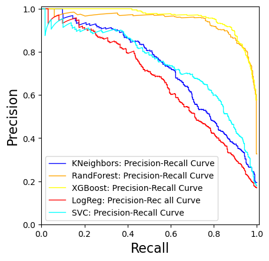

```python
from sklearn.metrics import precision_recall_curve

y_proba_knn = knn_grid.best_estimator_.fit(X_train_s_pca, y_train).predict_proba(X_test_s_pca)
y_proba_rfc = rfc_grid.best_estimator_.fit(X_train, y_train).predict_proba(X_test)
y_proba_xgbc = xgbc_grid.best_estimator_.fit(X_train, y_train).predict_proba(X_test)
y_scores_logr = logr_grid.best_estimator_.fit(X_train_s_pca, y_train).decision_function(X_test_s_pca)
y_scores_svc = svc_grid.best_estimator_.fit(X_train_s_pca, y_train).decision_function(X_test_s_pca)


knn_precision, knn_recall, knn_thresholds = precision_recall_curve(y_test, y_proba_knn[:,1])
rfc_precision, rfc_recall, rfc_thresholds = precision_recall_curve(y_test, y_proba_rfc[:,1])
xgbc_precision, xgbc_recall, xgbc_thresholds = precision_recall_curve(y_test, y_proba_xgbc[:,1])
logr_precision, logr_recall, logr_thresholds = precision_recall_curve(y_test, y_scores_logr)
svc_precision, svc_recall, svc_thresholds = precision_recall_curve(y_test, y_scores_svc)


plt.xlim([0.0, 1.01])
plt.ylim([0.0, 1.01])
plt.plot(knn_recall, knn_precision, lw=1, label='KNeighbors: Precision-Recall Curve', color='blue')
plt.plot(rfc_recall, rfc_precision, lw=1, label='RandForest: Precision-Recall Curve', color='orange')
plt.plot(xgbc_recall, xgbc_precision, lw=1, label='XGBoost: Precision-Recall Curve', color='yellow')
plt.plot(logr_recall , logr_precision, lw=1,  label='LogReg: Precision-Rec all Curve', color='red')
plt.plot(svc_recall, svc_precision, lw=1, label='SVC: Precision-Recall Curve', color='cyan')
plt.xlabel('Recall', fontsize=16)
plt.ylabel('Precision', fontsize=16)
plt.legend(loc='lower left', fontsize=10)
plt.axes().set_aspect('equal')
plt.show();
```

## Receiver Operating Characteristic curve (ROC)

ROC curves or Receiver Operating Characteristic curves illustrate the performance of a binary classifier. It is created by plotting the true positive rate (TPR) (or recall) against the false positive rate (FPR).

ROC curves on the X-axis show a classifier's False Positive Rate so that would go from 0 to 1.0, and on the Y-axis they show a classifier's True Positive Rate so that will also go from 0 to 1.0.

ROC curves are very help with understanding the balance between true-positive rate and false positive rate.

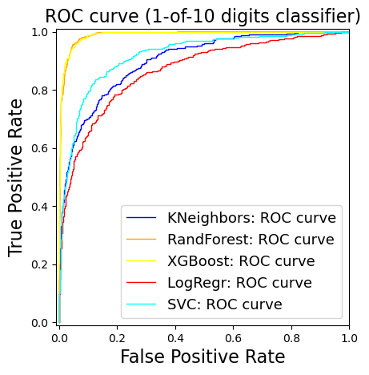

```python
# import necessary packages
from sklearn.metrics import roc_curve, auc, roc_auc_score

fpr_knn, tpr_knn, _ = roc_curve(y_test, y_proba_knn[:,1])
fpr_rfc, tpr_rfc, _ = roc_curve(y_test, y_proba_rfc[:,1])
fpr_xgbc, tpr_xgbc, _ = roc_curve(y_test, y_proba_xgbc[:,1])
fpr_logr, tpr_logr, _ = roc_curve(y_test, y_scores_logr)
fpr_svc, tpr_svc, _ = roc_curve(y_test, y_scores_svc)


plt.xlim([-0.01, 1.00])
plt.ylim([-0.01, 1.01])
plt.plot(fpr_knn, tpr_knn, lw=1, label='KNeighbors: ROC curve', color='blue')
plt.plot(fpr_rfc, tpr_rfc, lw=1, label='RandForest: ROC curve', color='orange')
plt.plot(fpr_xgbc, tpr_xgbc, lw=1, label='XGBoost: ROC curve', color='yellow')
plt.plot(fpr_logr, tpr_logr, lw=1, label='LogRegr: ROC curve', color='red')
plt.plot(fpr_svc, tpr_svc, lw=1, label='SVC: ROC curve', color='cyan')
plt.xlabel('False Positive Rate', fontsize=16)
plt.ylabel('True Positive Rate', fontsize=16)
plt.title('ROC curve (1-of-10 digits classifier)', fontsize=16)
plt.legend(loc='lower right', fontsize=13)
plt.axes().set_aspect('equal')
plt.show();
```

## AUC

Let's see the AUC score for each models

```python
# AUC

print(f"AUC score for KNN {auc(fpr_knn, tpr_knn) :.2f}")
print(f"AUC score for Random Forest {auc(fpr_rfc, tpr_rfc) :.2f}")
print(f"AUC score for XGBoost {auc(fpr_xgbc, tpr_xgbc) :.2f}")
print(f"AUC score for LogReg {auc(fpr_logr, tpr_logr) :.2f}")
print(f"AUC score for SVC Non-linear {auc(fpr_svc, tpr_svc) :.2f}")
```

```
AUC score for KNN 0.90
AUC score for Random Forest 0.99
AUC score for XGBoost 0.99
AUC score for LogReg 0.87
AUC score for SVC Non-linear 0.92
```

# Summary

XGBoost and Random Forest has the best model compared to the other with all metrics score (precision, recall, f1, accuracy) has shown at least 85% accuracy. Also, both XGBoost and Random Forest have AUC score of 99% that shows the model is learning the data well enough.

Even though most of the models are improving in their recall score, some of the models have significant reduction in their precision score; which are KNN, Logistic Regression, and Support Vector Machine. This is important as we must aware by getting a high recall score and a low precision score, it could be a sign that the model might simply predicting customer that want to churn their credit card (increasing in **False Positive**)